# Project 1: Wrangling, Exploration, Visualization

SDS322E

## Data Wrangling, Exploration, Visualization

### Lingyu Yan ly4423

#### Introduction

data1 is global education statistics including multiple comparable indicators such as education access from 2000 to 2014. data2 is global environment, social and governance statistics which provides information on 17 themes from 2000 to 2014. Many countries have been focused on these two topics and done a lot of research on them because both education and environment can have great influence on social development and financial markets.

```r
# read your datasets in here, e.g., with read_csv()
library(tidyverse)
library(stringr)
data1 <- read_csv("~/EdStats1.csv")
data2 <- read_csv("~/ESGData3.csv")
```

#### Tidying: Reshaping

If your datasets are tidy already, demonstrate that you can reshape data with pivot wider/longer here (e.g., untidy and then retidy). Alternatively, it may be easier to wait until the wrangling section so you can reshape your summary statistics. Note here if you are going to do this.

```r
# your tidying code (if applicable; can also wait until
# wrangling section)
data11 <- data1 %>% pivot_longer(5:19, names_to = "Year1", values_to = "EdValue")
data22 <- data2 %>% pivot_longer(5:19, names_to = "Year2", values_to = "ESGValue")
data11
```

```
## # A tibble: 186,960 x 6
##    CountryName CountryCode IndicatorName             IndicatorCode Year1 EdValue
##    <chr>       <chr>       <chr>                     <chr>         <chr>   <dbl>
##  1 Arab World  ARB         Adjusted net enrolment r… UIS.NERA.2    2000       NA
##  2 Arab World  ARB         Adjusted net enrolment r… UIS.NERA.2    2001       NA
##  3 Arab World  ARB         Adjusted net enrolment r… UIS.NERA.2    2002       NA
##  4 Arab World  ARB         Adjusted net enrolment r… UIS.NERA.2    2003       NA
##  5 Arab World  ARB         Adjusted net enrolment r… UIS.NERA.2    2004       NA
##  6 Arab World  ARB         Adjusted net enrolment r… UIS.NERA.2    2005       NA
##  7 Arab World  ARB         Adjusted net enrolment r… UIS.NERA.2    2006       NA
##  8 Arab World  ARB         Adjusted net enrolment r… UIS.NERA.2    2007       NA
##  9 Arab World  ARB         Adjusted net enrolment r… UIS.NERA.2    2008       NA
## 10 Arab World  ARB         Adjusted net enrolment r… UIS.NERA.2    2009       NA
## # … with 186,950 more rows
```

```r
data22
```

```
## # A tibble: 240,195 x 6
##    CountryName CountryCode IndicatorName            IndicatorCode Year2 ESGValue
##    <chr>       <chr>       <chr>                    <chr>         <chr>    <dbl>
##  1 Arab World  ARB         Access to clean fuels a… EG.CFT.ACCS.… 2000      73.7
##  2 Arab World  ARB         Access to clean fuels a… EG.CFT.ACCS.… 2001      74.9
##  3 Arab World  ARB         Access to clean fuels a… EG.CFT.ACCS.… 2002      76.3
##  4 Arab World  ARB         Access to clean fuels a… EG.CFT.ACCS.… 2003      77.1
##  5 Arab World  ARB         Access to clean fuels a… EG.CFT.ACCS.… 2004      78.1
##  6 Arab World  ARB         Access to clean fuels a… EG.CFT.ACCS.… 2005      79.1
##  7 Arab World  ARB         Access to clean fuels a… EG.CFT.ACCS.… 2006      79.9
##  8 Arab World  ARB         Access to clean fuels a… EG.CFT.ACCS.… 2007      80.6
##  9 Arab World  ARB         Access to clean fuels a… EG.CFT.ACCS.… 2008      81.2
## 10 Arab World  ARB         Access to clean fuels a… EG.CFT.ACCS.… 2009      81.8
## # … with 240,185 more rows
```

#### Joining/Merging

```r
# your joining code
data3 <- data22 %>% inner_join(data11, by = c("CountryName",
    Year2 = "Year1"))
data3
```

```
## # A tibble: 12,526,320 x 10
##    CountryName CountryCode.x IndicatorName.x IndicatorCode.x Year2 ESGValue
##    <chr>       <chr>         <chr>           <chr>           <chr>    <dbl>
##  1 Arab World  ARB           Access to clea… EG.CFT.ACCS.ZS  2000      73.7
##  2 Arab World  ARB           Access to clea… EG.CFT.ACCS.ZS  2000      73.7
##  3 Arab World  ARB           Access to clea… EG.CFT.ACCS.ZS  2000      73.7
##  4 Arab World  ARB           Access to clea… EG.CFT.ACCS.ZS  2000      73.7
##  5 Arab World  ARB           Access to clea… EG.CFT.ACCS.ZS  2000      73.7
##  6 Arab World  ARB           Access to clea… EG.CFT.ACCS.ZS  2000      73.7
##  7 Arab World  ARB           Access to clea… EG.CFT.ACCS.ZS  2000      73.7
##  8 Arab World  ARB           Access to clea… EG.CFT.ACCS.ZS  2000      73.7
##  9 Arab World  ARB           Access to clea… EG.CFT.ACCS.ZS  2000      73.7
## 10 Arab World  ARB           Access to clea… EG.CFT.ACCS.ZS  2000      73.7
## # … with 12,526,310 more rows, and 4 more variables: CountryCode.y <chr>,
## #   IndicatorName.y <chr>, IndicatorCode.y <chr>, EdValue <dbl>
```

```r
data3 %>% distinct(CountryName)
```

```
## # A tibble: 12 x 1
##    CountryName
##    <chr>
##  1 Arab World
##  2 China
##  3 Guinea
##  4 Honduras
##  5 Italy
##  6 Jamaica
##  7 Liberia
##  8 Monaco
##  9 Netherlands
## 10 Spain
## 11 United States
## 12 Vietnam
```

```r
data22 %>% anti_join(data11, by = c("CountryName", Year2 = "Year1")) %>%
    distinct(CountryName)
```

```
## # A tibble: 227 x 1
##    CountryName
##    <chr>
##  1 Caribbean small states
##  2 Central Europe and the Baltics
##  3 Early-demographic dividend
##  4 East Asia & Pacific
##  5 East Asia & Pacific (excluding high income)
##  6 Euro area
##  7 Europe & Central Asia
##  8 Europe & Central Asia (excluding high income)
##  9 European Union
## 10 Fragile and conflict affected situations
## # … with 217 more rows
```

I used inner_join to drop rows in either dataset without a match and there were 12 distinct observations in common and 227 that appear in one dataset but not the other.

```r
# your joining code
data1
```

```
## # A tibble: 12,464 x 19
##    CountryName CountryCode IndicatorName IndicatorCode `2000` `2001` `2002`
##    <chr>       <chr>       <chr>         <chr>          <dbl>  <dbl>  <dbl>
##  1 Arab World  ARB         Adjusted net… UIS.NERA.2    NA     NA     NA
##  2 Arab World  ARB         Adjusted net… UIS.NERA.2.F  NA     NA     NA
##  3 Arab World  ARB         Adjusted net… UIS.NERA.2.G… NA     NA     NA
##  4 Arab World  ARB         Adjusted net… UIS.NERA.2.M  NA     NA     NA
##  5 Arab World  ARB         Adjusted net… SE.PRM.TENR   77.2   78.8   80.1
##  6 Arab World  ARB         Adjusted net… SE.PRM.TENR.… 73.3   75.1   76.6
##  7 Arab World  ARB         Adjusted net… UIS.NERA.1.G…  0.904  0.913  0.920
##  8 Arab World  ARB         Adjusted net… SE.PRM.TENR.… 81.1   82.3   83.3
##  9 Arab World  ARB         Adjusted net… UIS.NERA.3    NA     NA     NA
## 10 Arab World  ARB         Adjusted net… UIS.NERA.3.F  NA     NA     NA
## # … with 12,454 more rows, and 12 more variables: `2003` <dbl>, `2004` <dbl>,
## #   `2005` <dbl>, `2006` <dbl>, `2007` <dbl>, `2008` <dbl>, `2009` <dbl>,
## #   `2010` <dbl>, `2011` <dbl>, `2012` <dbl>, `2013` <dbl>, `2014` <dbl>
```

```r
data2
```

```
## # A tibble: 16,013 x 19
##    CountryName CountryCode IndicatorName IndicatorCode  `2000`  `2001`  `2002`
##    <chr>       <chr>       <chr>         <chr>           <dbl>   <dbl>   <dbl>
##  1 Arab World  ARB         Access to cl… EG.CFT.ACCS.… 73.7    74.9    76.3
##  2 Arab World  ARB         Access to el… EG.ELC.ACCS.… 78.9    79.6    77.5
##  3 Arab World  ARB         Adjusted sav… NY.ADJ.DRES.… 10.3     7.89    7.88
##  4 Arab World  ARB         Adjusted sav… NY.ADJ.DFOR.…  0.0308  0.0359  0.0395
##  5 Arab World  ARB         Agricultural… AG.LND.AGRI.… 36.3    36.3    36.4
##  6 Arab World  ARB         Agriculture,… NV.AGR.TOTL.…  7.45    7.89    7.76
##  7 Arab World  ARB         Annual fresh… ER.H2O.FWTL.… NA      NA      NA
##  8 Arab World  ARB         Annualized a… SI.SPR.PCAP.… NA      NA      NA
##  9 Arab World  ARB         Cause of dea… SH.DTH.COMM.… 32.0    NA      NA
## 10 Arab World  ARB         Children in … SL.TLF.0714.… NA      NA      NA
## # … with 16,003 more rows, and 12 more variables: `2003` <dbl>, `2004` <dbl>,
## #   `2005` <dbl>, `2006` <dbl>, `2007` <dbl>, `2008` <dbl>, `2009` <dbl>,
## #   `2010` <dbl>, `2011` <dbl>, `2012` <dbl>, `2013` <dbl>, `2014` <dbl>
```

```r
data3 %>% summarize(n_distinct(CountryName))
```

```
## # A tibble: 1 x 1
##   `n_distinct(CountryName)`
##                       <int>
## 1                        12
```

```r
data1 %>% summarize(n_distinct(CountryName))
```

```
## # A tibble: 1 x 1
##   `n_distinct(CountryName)`
##                       <int>
## 1                        12
```

```r
data2 %>% summarize(n_distinct(CountryName))
```

```
## # A tibble: 1 x 1
##   `n_distinct(CountryName)`
##                       <int>
## 1                       239
```

```r
239 - 12
```

```
## [1] 227
```

Originally, there are 12,464 rows and 12 distinct observations in data1; 16,013 rows and 239 distinct observations in data2. Therefore, data2 contains all observations in data1 and dropped 227 observations after doing the join.

#### Wrangling

```r
# your wrangling code
data3 %>% mutate(prob = ESGValue/EdValue)
```

```
## # A tibble: 12,526,320 x 11
##    CountryName CountryCode.x IndicatorName.x IndicatorCode.x Year2 ESGValue
##    <chr>       <chr>         <chr>           <chr>           <chr>    <dbl>
##  1 Arab World  ARB           Access to clea… EG.CFT.ACCS.ZS  2000      73.7
##  2 Arab World  ARB           Access to clea… EG.CFT.ACCS.ZS  2000      73.7
##  3 Arab World  ARB           Access to clea… EG.CFT.ACCS.ZS  2000      73.7
##  4 Arab World  ARB           Access to clea… EG.CFT.ACCS.ZS  2000      73.7
##  5 Arab World  ARB           Access to clea… EG.CFT.ACCS.ZS  2000      73.7
##  6 Arab World  ARB           Access to clea… EG.CFT.ACCS.ZS  2000      73.7
##  7 Arab World  ARB           Access to clea… EG.CFT.ACCS.ZS  2000      73.7
##  8 Arab World  ARB           Access to clea… EG.CFT.ACCS.ZS  2000      73.7
##  9 Arab World  ARB           Access to clea… EG.CFT.ACCS.ZS  2000      73.7
## 10 Arab World  ARB           Access to clea… EG.CFT.ACCS.ZS  2000      73.7
## # … with 12,526,310 more rows, and 5 more variables: CountryCode.y <chr>,
## #   IndicatorName.y <chr>, IndicatorCode.y <chr>, EdValue <dbl>, prob <dbl>
```

```r
data3 %>% distinct(CountryName) %>% filter(str_detect(CountryName,
    "[ ]"))
```

```
## # A tibble: 2 x 1
##   CountryName
##   <chr>
## 1 Arab World
## 2 United States
```

I used mutate to generate the ratio of environment, social and governance value (ESGValue) to education value (EdValue) and find the country names which has a space in the name (Arab World and United States.

```r
# your wrangling code
data3.1 <- data3 %>% group_by(CountryName) %>% summarize(mean_EdVal = mean(EdValue,
    na.rm = T), sd_EdVal = sd(EdValue, na.rm = T), var_EdVal = var(EdValue,
    na.rm = T), n()) %>% na.omit()
data3.1
```

```
## # A tibble: 11 x 5
##    CountryName   mean_EdVal  sd_EdVal var_EdVal   `n()`
##    <chr>              <dbl>     <dbl>     <dbl>   <int>
##  1 Arab World      4549094. 13219465.   1.75e14 1138665
##  2 China            856424.  5040803.   2.54e13 1138665
##  3 Honduras           7985.    57437.   3.30e 9 1138665
##  4 Italy             29182.   171690.   2.95e10 1138665
##  5 Jamaica             942.     8260.   6.82e 7 1138665
##  6 Liberia            1976.    37191.   1.38e 9 1138665
##  7 Monaco              123.      207.   4.28e 4 1138665
##  8 Netherlands        8118.    38935.   1.52e 9 1138665
##  9 Spain             23823.   120306.   1.45e10 1138665
## 10 United States    135808.   845305.   7.15e11 1138665
## 11 Vietnam           84980.   427985.   1.83e11 1138665
```

```r
data3.1 %>% slice_max(mean_EdVal, n = 1)
```

```
## # A tibble: 1 x 5
##   CountryName mean_EdVal  sd_EdVal var_EdVal   `n()`
##   <chr>            <dbl>     <dbl>     <dbl>   <int>
## 1 Arab World    4549094. 13219465.   1.75e14 1138665
```

```r
data3.1 %>% slice_min(mean_EdVal, n = 1)
```

```
## # A tibble: 1 x 5
##   CountryName mean_EdVal sd_EdVal var_EdVal   `n()`
##   <chr>            <dbl>    <dbl>     <dbl>   <int>
## 1 Monaco            123.     207.    42772. 1138665
```

I found the mean, standard deviation, variance, and the maximum and minimum values of the education values of 11 countries (one country loses data). Arab World has the largest mean of value in education of different indicators and Monaco has the smallest. However, this may not mean that Arab World has the greatest education or Monaco has the worest in the world. The value may be influenced by many factors such as population.

#### Visualizing

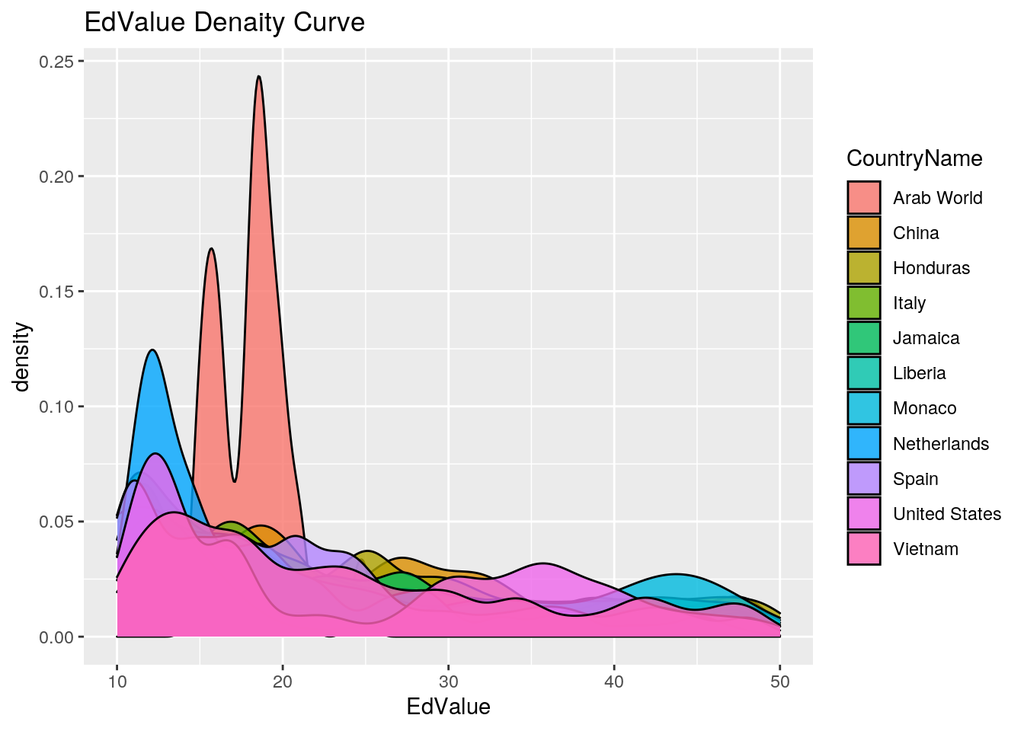

```r
# your plot 1
library(ggplot2)
data3.1 <- data3 %>% na.omit()
ggplot(data3.1, aes(x = EdValue, fill = CountryName)) + geom_density(alpha = 0.8) +
    scale_x_continuous(limits = c(10, 50)) + ggtitle("EdValue Denaity Curve")
```

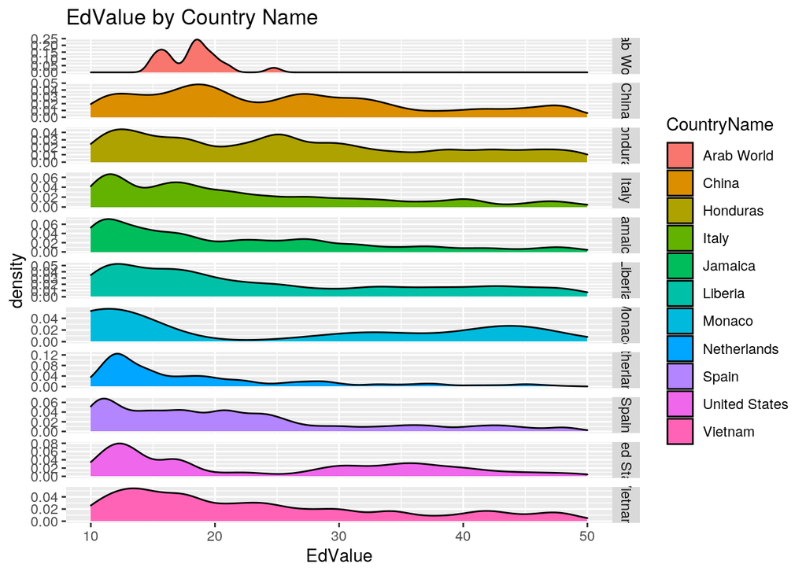

```r
# your plot 2
ggplot(data3.1, aes(x = EdValue, fill = CountryName)) + geom_density(alpha = 10) +
    scale_x_continuous(limits = c(10, 50)) + facet_grid(CountryName ~
    ., scales = "free_y") + ggtitle("EdValue by Country Name")
```

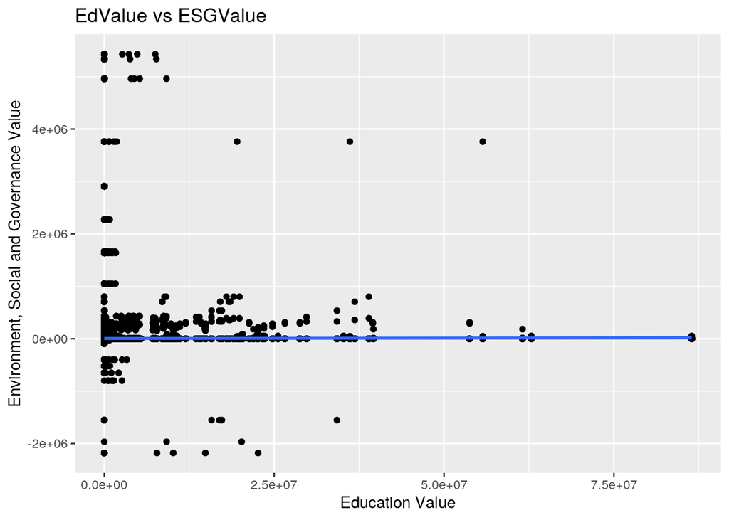

```r
# your plot 3
ggplot(data3.1, aes(EdValue, ESGValue)) + geom_point() + geom_smooth(formula = y ~
    x, method = "lm", se = F) + ggtitle("EdValue vs ESGValue") +
    xlab("Education Value") + ylab("Environment, Social and Governance Value")
```

This plot shows the relationship between education value and environment, social and governance value. There is no relationship between these two values.